I am restricted the charts to show values on March 15, 2020 and after. This is when cases numbers started to rise and preventative measures started to increase dramatically.

### Is the pandemic slowing?

One important calculation is the growth factor, as outlined in [3Blue1Brown’s youtube video on exponential growth](https://www.youtube.com/watch?v=Kas0tIxDvrg) . The growth rate is calculated as follows:

$$\text{Growth Factor} = \frac{ \text{New-Cases}_N}{\text{New-Cases}_{N-1}}$$
where $N$ is a given day. Essentialy this is taking the amount new cases today and dividing them by the amount of new cases yesterday.

The growth factor can be very helpful in determining if the pandemic is slowing. If the growth factor is less than 1, this means that the amount of new cases today is less than yesterday. Once there are multiple days with a growth factor less than 1 - this is a strong sign that the pandemic is slowing down.

**Adjustment to Growth Factor**  
What if there were 0 cases yesterday? This would make the growth factor undefined (or $\infty$ according to R). This makes it difficult to look at trends. I have adjusted the growth factor so that if the pervious day had 0 cases; the current day’s growth factor is equal to the number of new cases:

$$\text{Growth Factor} = \begin{cases}
\frac{ \text{New-Cases}_N}{\text{New-Cases}_{N-1}} & \text{if } \text{New-Cases}_{N-1} \neq 0
\\[1ex]
\text{New-Cases}_N & \text{if } \text{New-Cases}_{N-1} = 0
\end{cases}$$
When I made this adjustment I was thinking about the early stages of the pandemic when the number of cases per day are 0, 1, or 2. However, given the test scarcity and reporting times there are situations in counties or states where there were 0 cases one day and then hundred or thousands the next day. This is why some of growth factors are much larger.

Similar to the new cases per day; there can be a lot of variability in growth rates. In order to get a better sense of the trend I am showing a 14-day moving average of the growth factor.

The growth rate shows a different trend than new cases. Here, the growth rate has stayed around 1 since mid-April. Compare that to the new cases plot on the Overview tab, which shows a downward trends. The the growth factor remaining around 1 due may be due to the cyclical nature of new cases reporting (high during the week, low during the weekends) - but it could also be showing that although the decrease in new cases is positive we are not out of the woods yet.

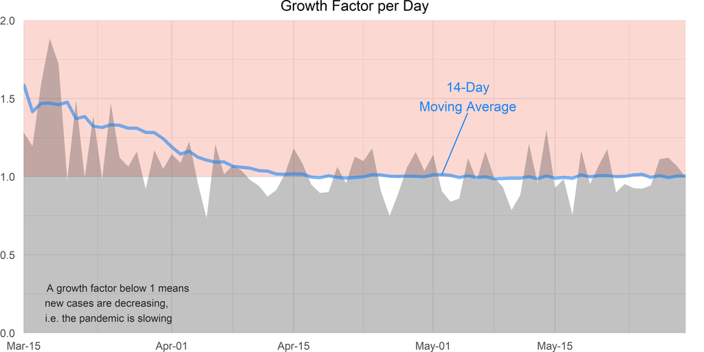

### Recent Values by Day for US

| Date | Total Cases | New Cases | New Cases 14-Day MA | Growth Factor | Growth Factor 14-day MA |
| --- | --- | --- | --- | --- | --- |
| Sat, May 30, 2020 | 1,760,305 | 23,919 | 21,613 | 1 | 1.01 |
| Fri, May 29, 2020 | 1,736,386 | 24,011 | 21,655 | 1.07 | 1 |
| Thu, May 28, 2020 | 1,712,375 | 22,482 | 21,719 | 1.12 | 0.99 |
| Wed, May 27, 2020 | 1,689,893 | 20,049 | 22,027 | 1.11 | 1.01 |
| Tue, May 26, 2020 | 1,669,844 | 18,011 | 22,068 | 0.94 | 1 |
| Mon, May 25, 2020 | 1,651,833 | 19,066 | 22,317 | 0.92 | 1.01 |
| Sun, May 24, 2020 | 1,632,767 | 20,645 | 22,224 | 0.93 | 1.01 |
| Sat, May 23, 2020 | 1,612,122 | 22,277 | 22,187 | 0.95 | 1 |
| Fri, May 22, 2020 | 1,589,845 | 23,357 | 22,423 | 0.9 | 1 |
| Thu, May 21, 2020 | 1,566,488 | 25,951 | 22,711 | 1.18 | 1.01 |
| Wed, May 20, 2020 | 1,540,537 | 22,069 | 22,820 | 1.07 | 1.01 |
| Tue, May 19, 2020 | 1,518,468 | 20,607 | 22,934 | 0.95 | 1 |
| Mon, May 18, 2020 | 1,497,861 | 21,621 | 23,193 | 1.17 | 1.01 |
| Sun, May 17, 2020 | 1,476,240 | 18,517 | 23,195 | 0.76 | 0.99 |

### Recent Growth Factor for each state

Since most of the COVID-19 measures are enacted by the state; it may be more helpful for the individual to see the growth factor for the last 14 days in a specific state.

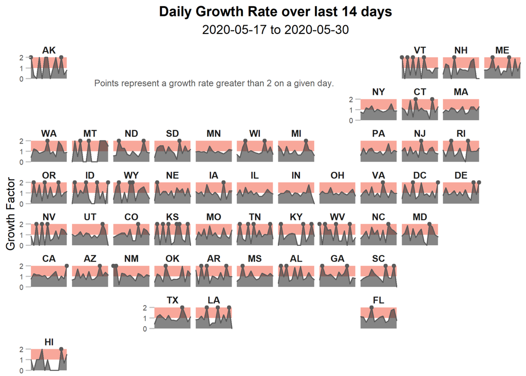

### Still want to look at more plots?

Build your own growth factor plot for a given state and time period by using a shiny app. The app ca can be access through this link, mareichler.shinyapps.io/state_gf/, and is also embedded below:

[interactive chart not shown]

### Growth Rate 14-day moving average or growth rate on 14-day moving average of new cases?

What if instead of looking at the growth rate and average of the growth rate - we calculated the growth rate on the average of new cases? I’m going to call this $\text{GF}_{14}$ to represent that it’s the growth rate based on the 14-day moving average of new cases.

Looking at the new cases 14-day moving average, it is clearly smoother than the raw new cases.

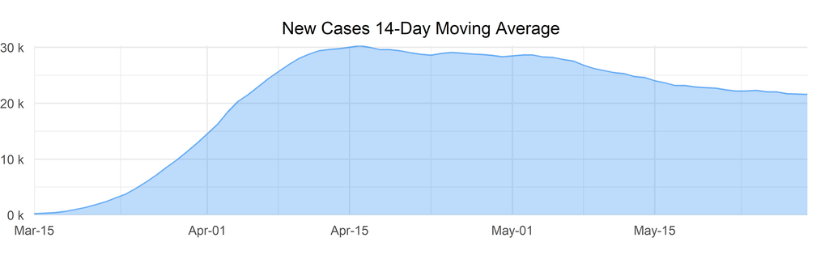

Using the new cases 14-day moving average, calculate the $\text{GF}_{14}$:

$$\text{GF}_{14} = \frac{
\frac{1}{14}\sum_{N-14}^N \text{New-Cases}_i
}{
\frac{1}{14}\sum_{N-15}^{N - 1} \text{New-Cases}_i
}$$

I am showing both the growth factor 14-day moving average and the $\text{GF}_{14}$ for comparison.

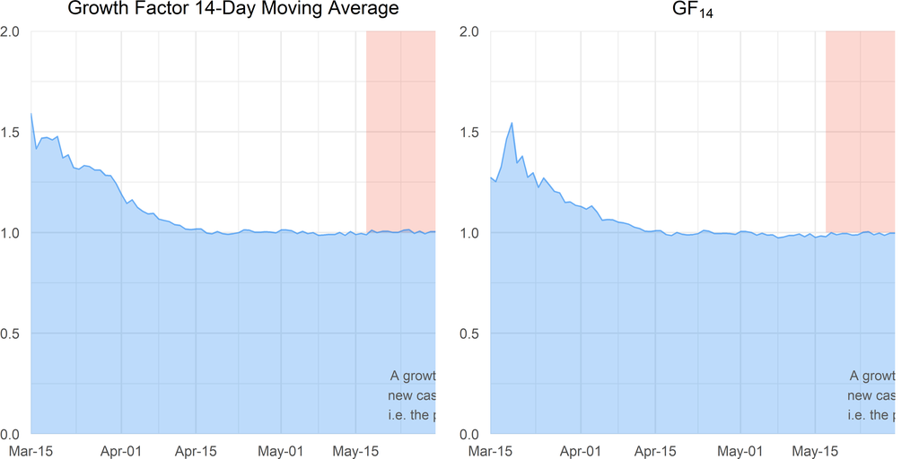

Turns out it doesn’t make a significant difference! Even when looking the growth rate based on the 14-day moving average of new cases (smoothing over the cyclical nature of new cases reporting) - results is a growth factor, $\text{GF}_{14}$ that is not deviating from 1.

Standard Deviations

|  | Growth Rate | Growth Factor 14-day MA | GF_14 |
| --- | --- | --- | --- |
| All dates | 0.7155527 | 0.3240225 | 0.2356262 |
| Since 2020-03-15 | 0.2027367 | 0.1587231 | 0.1272451 |
| Last 14 days | 0.1190668 | 0.0071677 | 0.0069073 |

Looking at the standard deviations, it’s unsurpising that the $\text{GF}_{14}$ has the least amount of deviation, followed by the Growth Rate 14-day Moiving average, and the raw Growth Rate has the most deviation.

Since there isn’t a large difference between $\text{GF}_{14}$ and Growth Rate 14-Day Moving Average, I’m going to use the Growth Rate 14-Day Moving Average instead of $\text{GF}_{14}$. When possible, I want to keep the calculations as simple and close to the raw data as possible.